# hyperparameter-tuning

Ecosystem Science and Sustainability 330

Author

Jake Matullo

```r
library(tidyverse)
library(tidymodels)
library(powerjoin)
library(glue)
library(vip)
library(baguette)
library(workflows)
library(rsample)
library(recipes)
library(tune)
library(ranger)
library(xgboost)
library(nnet)
library(dplyr)
library(patchwork)
```

```r
root  <- 'https://gdex.ucar.edu/dataset/camels/file'

download.file('https://gdex.ucar.edu/dataset/camels/file/camels_attributes_v2.0.pdf',
              'data/camels_attributes_v2.0.pdf')

types <- c("clim", "geol", "soil", "topo", "vege", "hydro")
remote_files  <- glue('{root}/camels_{types}.txt')
local_files   <- glue('data/camels_{types}.txt')

walk2(remote_files, local_files, download.file, quiet = TRUE)
camels <- map(local_files, read_delim, show_col_types = FALSE)

camels <- map(local_files, read_delim, show_col_types = FALSE)

camels <- power_full_join(camels ,by = 'gauge_id')
```

```r
camels %>% drop_na()
```

```
# A tibble: 507 × 58
   gauge_id p_mean pet_mean p_seasonality frac_snow aridity high_prec_freq
   <chr>     <dbl>    <dbl>         <dbl>     <dbl>   <dbl>          <dbl>
 1 01022500   3.61     2.12       -0.115      0.245   0.587           20.6
 2 01031500   3.52     2.07        0.104      0.292   0.588           18.9
 3 01047000   3.32     2.09        0.148      0.280   0.629           20.1
 4 01052500   3.73     2.10        0.152      0.353   0.562           13.5
 5 01054200   4.07     2.13        0.105      0.300   0.523           17.5
 6 01055000   3.49     2.09        0.167      0.306   0.599           19.2
 7 01057000   3.57     2.13        0.0791     0.251   0.597           20.4
 8 01073000   3.50     2.21        0.0304     0.175   0.630           20.8
 9 01078000   3.56     2.18        0.110      0.240   0.613           21.4
10 01118300   3.90     2.31       -0.0377     0.111   0.593           21.5
# ℹ 497 more rows
# ℹ 51 more variables: high_prec_dur <dbl>, high_prec_timing <chr>,
#   low_prec_freq <dbl>, low_prec_dur <dbl>, low_prec_timing <chr>,
#   geol_1st_class <chr>, glim_1st_class_frac <dbl>, geol_2nd_class <chr>,
#   glim_2nd_class_frac <dbl>, carbonate_rocks_frac <dbl>, geol_porostiy <dbl>,
#   geol_permeability <dbl>, soil_depth_pelletier <dbl>,
#   soil_depth_statsgo <dbl>, soil_porosity <dbl>, soil_conductivity <dbl>, …
```

```r
set.seed(123)
camels_select8 <- camels %>%
  mutate(logQmean = log(q_mean + 1)) %>%
  select(logQmean, aridity, q_mean, p_mean, pet_mean, p_seasonality, gauge_lat, gauge_lon) %>%
  drop_na()
```

```r
camels_split8 <- initial_split(camels_select8, prop = 0.8)

camels_train8 <- training(camels_split8)

camels_test8  <- testing(camels_split8)

camels_cv8 <- vfold_cv(camels_train8, v = 10)
```

```r
rec8 <-  recipe(logQmean ~ ., data = camels_train8) %>%
  step_rm(gauge_lon, gauge_lat) %>%
  step_normalize(all_predictors()) %>%
  step_interact(terms = ~ aridity:q_mean)
```

```r
rf_model8 <- rand_forest() %>%
  set_engine("ranger") %>%
  set_mode("regression")

lm_model8 <- linear_reg() %>%
  set_engine("lm") %>%
  set_mode("regression")

boost_model8 <- boost_tree() %>%
  set_engine("xgboost") %>%
  set_mode("regression")
```

```r
wf8 <- workflow_set(list(rec8), list(rf_model8, lm_model8, boost_model8)) %>%
  workflow_map('fit_resamples', resamples = camels_cv8)
```

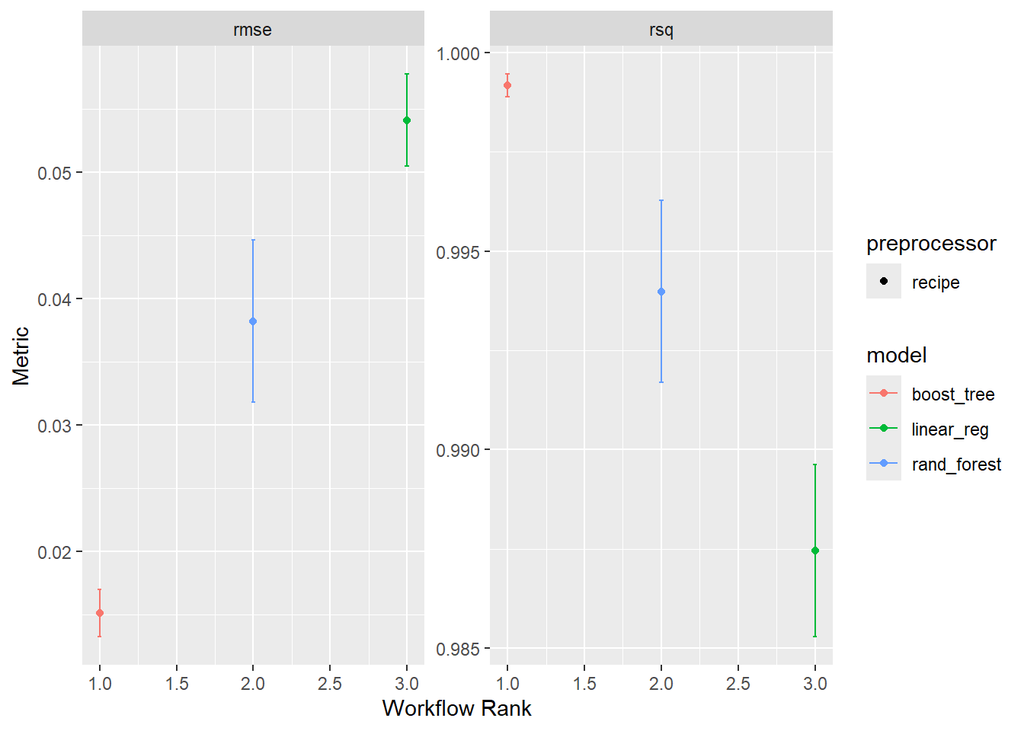

```r
autoplot(wf8)
```

The ideal model for this would be the boost tree, with the engine set to “xgboost” and the the mode set to “regression.” This is due to the fact that it has the highest rsq score and the lowest rmse score. The reason for this high performance could be because the camels data just really fits well with a boost tree model when compared to the other models we tested.

```r
boost_model8 <-
  boost_tree(
    trees = 1000,
    tree_depth = tune(),
    loss_reduction = tune()) %>%
  set_engine("xgboost") %>%
  set_mode("regression")
```

```r
new_wf8 <- workflow(rec8, boost_model8)
```

```r
camels_metrics8 <- metric_set(rsq, rmse, mae)
```

```r
dials <- extract_parameter_set_dials(new_wf8)
```

```r
my.grid <- grid_space_filling(dials, size = 20)
```

```r
model_params <-  tune_grid(
    new_wf8,
    resamples = camels_cv8,
    grid = my.grid,
    metrics = metric_set(rmse, rsq, mae),
    control = control_grid(save_pred = TRUE)
  )
```

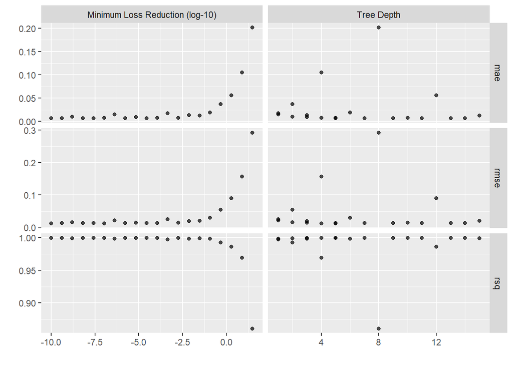

```r
autoplot(model_params)
```

```r
collect_metrics(model_params)
```

```
# A tibble: 60 × 8
   tree_depth loss_reduction .metric .estimator   mean     n  std_err .config
        <int>          <dbl> <chr>   <chr>       <dbl> <int>    <dbl> <chr>
 1          1  0.000000428   mae     standard   0.0148    10 0.00103  Preproces…
 2          1  0.000000428   rmse    standard   0.0218    10 0.00134  Preproces…
 3          1  0.000000428   rsq     standard   0.998     10 0.000323 Preproces…
 4          1  0.000455      mae     standard   0.0172    10 0.00114  Preproces…
 5          1  0.000455      rmse    standard   0.0249    10 0.00138  Preproces…
 6          1  0.000455      rsq     standard   0.997     10 0.000369 Preproces…
 7          2  0.483         mae     standard   0.0372    10 0.00134  Preproces…
 8          2  0.483         rmse    standard   0.0544    10 0.00336  Preproces…
 9          2  0.483         rsq     standard   0.992     10 0.000647 Preproces…
10          2  0.00000000162 mae     standard   0.0104    10 0.000887 Preproces…
# ℹ 50 more rows
```

```r
show_best(model_params, metric = "mae", n = 5)
```

```
# A tibble: 5 × 8
  tree_depth loss_reduction .metric .estimator    mean     n  std_err .config
       <int>          <dbl> <chr>   <chr>        <dbl> <int>    <dbl> <chr>
1         13       2.80e- 5 mae     standard   0.00706    10 0.000673 Preproces…
2          7       6.54e- 9 mae     standard   0.00706    10 0.000597 Preproces…
3          5       1   e-10 mae     standard   0.00720    10 0.000568 Preproces…
4          9       1.73e- 6 mae     standard   0.00725    10 0.000652 Preproces…
5         11       4.03e-10 mae     standard   0.00726    10 0.000621 Preproces…
```

```r
show_best(model_params, metric = "rmse", n = 5)
```

```
# A tibble: 5 × 8
  tree_depth loss_reduction .metric .estimator   mean     n std_err .config
       <int>          <dbl> <chr>   <chr>       <dbl> <int>   <dbl> <chr>
1          5  0.0000000001  rmse    standard   0.0125    10 0.00128 Preprocesso…
2          4  0.000000106   rmse    standard   0.0126    10 0.00101 Preprocesso…
3          5  0.000113      rmse    standard   0.0131    10 0.00128 Preprocesso…
4         13  0.0000280     rmse    standard   0.0132    10 0.00171 Preprocesso…
5          7  0.00000000654 rmse    standard   0.0133    10 0.00153 Preprocesso…
```

```r
show_best(model_params, metric = "rsq", n = 5)
```

```
# A tibble: 5 × 8
  tree_depth loss_reduction .metric .estimator  mean     n  std_err .config
       <int>          <dbl> <chr>   <chr>      <dbl> <int>    <dbl> <chr>
1          4  0.000000106   rsq     standard   0.999    10 0.000106 Preprocesso…
2          5  0.0000000001  rsq     standard   0.999    10 0.000141 Preprocesso…
3          5  0.000113      rsq     standard   0.999    10 0.000151 Preprocesso…
4          7  0.00000000654 rsq     standard   0.999    10 0.000182 Preprocesso…
5         13  0.0000280     rsq     standard   0.999    10 0.000199 Preprocesso…
```

```r
hp_best <- select_best(model_params, metric = "rsq")
```

```r
final_wf8 <- finalize_workflow(new_wf8, hp_best)

fit = last_fit(final_wf8, camels_split8, metrics = camels_metrics8)
```

```r
collect_metrics(fit)
```

```
# A tibble: 3 × 4
  .metric .estimator .estimate .config
  <chr>   <chr>          <dbl> <chr>
1 rsq     standard     1.00    Preprocessor1_Model1
2 rmse    standard     0.00836 Preprocessor1_Model1
3 mae     standard     0.00567 Preprocessor1_Model1
```

The final model performs better all across the board, though usually only a hundredth of a decimal better or so. It is better than the training data results.

```r
collect_predictions(fit)
```

```
# A tibble: 134 × 5
   .pred id                .row logQmean .config
   <dbl> <chr>            <int>    <dbl> <chr>
 1 0.993 train/test split     1    0.993 Preprocessor1_Model1
 2 1.03  train/test split     3    1.04  Preprocessor1_Model1
 3 1.04  train/test split     9    1.04  Preprocessor1_Model1
 4 1.12  train/test split    15    1.12  Preprocessor1_Model1
 5 1.03  train/test split    18    1.03  Preprocessor1_Model1
 6 1.18  train/test split    22    1.17  Preprocessor1_Model1
 7 1.04  train/test split    35    1.03  Preprocessor1_Model1
 8 1.01  train/test split    42    1.02  Preprocessor1_Model1
 9 0.620 train/test split    43    0.617 Preprocessor1_Model1
10 0.691 train/test split    44    0.692 Preprocessor1_Model1
# ℹ 124 more rows
```

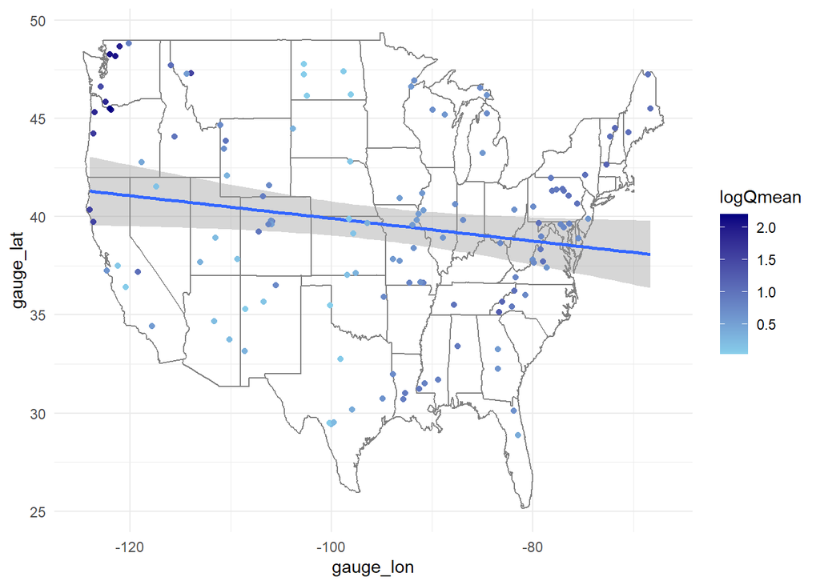

```r
xx = fit(final_wf8, data = camels_test8) %>%
  augment(new_data = camels_test8)

ggplot(data = xx, aes(x = gauge_lon, y = gauge_lat)) +
  borders("state", colour = "gray50") +
  geom_smooth(method = "lm") +
  geom_abline() +
  geom_point(aes(color = logQmean)) +
  scale_color_gradient(low = "skyblue", high = "navy") +
  theme_minimal()
```

```r
finalfullfit = fit(final_wf8, data = camels_select8) %>%
  augment(new_data = camels_select8) %>%
  mutate(residuals = .pred - (logQmean)^2)

g1 <- ggplot(data = finalfullfit, aes(x = gauge_lon, y = gauge_lat)) +
  borders("state", colour = "gray50") +
  geom_point(aes(color = .pred)) +
  scale_color_gradient(low = "skyblue", high = "navy") +
  theme_minimal()
```

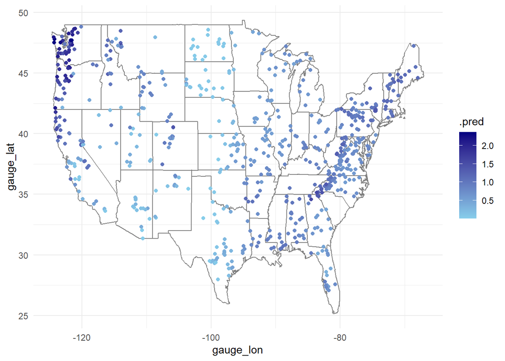

```r
print(g1)
```

```r
g2 <- ggplot(data = finalfullfit, aes(x = gauge_lon, y = gauge_lat)) +
  borders("state", colour = "gray50") +
  geom_point(aes(color = residuals)) +
  scale_color_gradient(low = "red", high = "green") +
  theme_minimal()
```

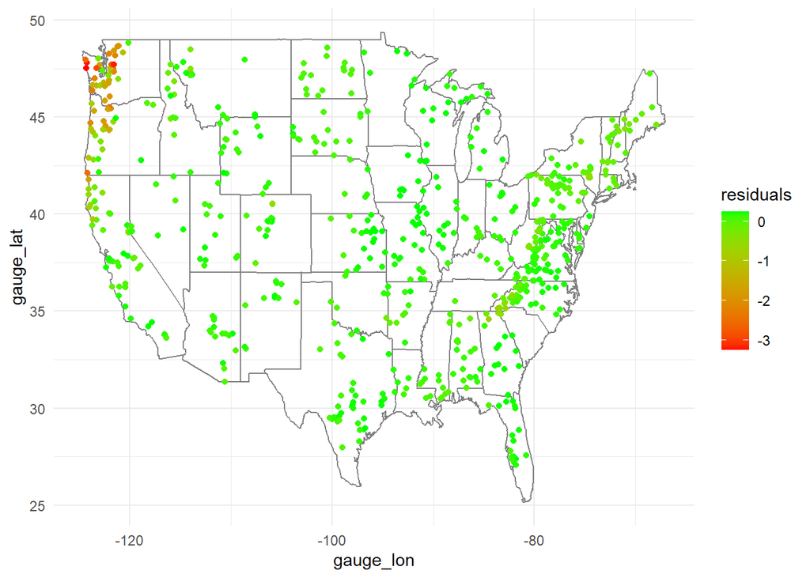

```r
print(g2)
```

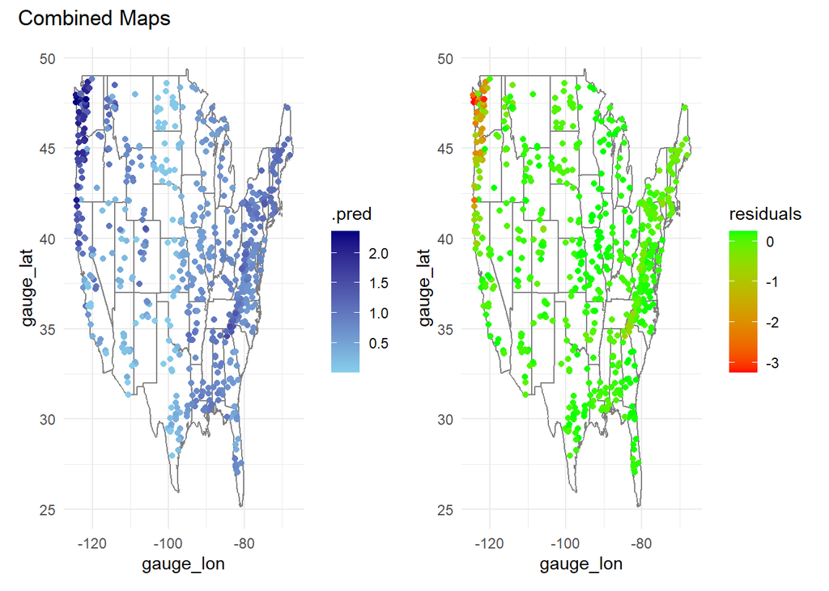

```r
(g1 + g2) + plot_annotation(title = "Combined Maps")
```